# Project 2: Data Mining, Classification, Prediction

SDS322E

# Mining, Classification, Prediction

## Tejas Karuturi, tk22543

### Introduction

*The datasets I chose are about Pokemon. I used to play Pokemon a lot back when I was younger, and I still play quite a bit to this day. One of my favorite content creators makes fire music about Pokemon, which made me even more interested. The first Pokemon dataset contains a Pokedex from Generation 1 to Generation 6, covering the Name, its typings, its stats, its generation, and whether it is a legendary pokemon or not. The second Pokemon dataset contains a Pokedex from Generation 1 to Generation 8, covering the Pokedex number, the pokemon name, its height and weight, its base experience, and whether it is a default pokemon.*

*This project classifies Pokemon data based on a merged dataset of two Pokemon datasets containing all the variables from both datasets. The numeric variables are Total, HP, Attack, Defense, Sp.Atk, Sp.Def, Speed, height, weight, and base experience. The categorical variables are the primary type, the secondary type, and the Generation. The binary variables are the Legendary status and the default status.*

```r
library(tidyverse)
# read your datasets in here, e.g., with read_csv()
pokemon1 <- read_csv("pokemon_dataset_1.csv")
pokemon2 <- read_csv("pokemon_dataset_2.csv")

# if your dataset needs tidying, do so here
poke1 <- pokemon1 %>% mutate(Name = tolower(Name))
poke2 <- pokemon2 %>% select(-id, -order, -species_id)

# any other code here
poke_join <- poke1 %>% full_join(poke2, by = c(Name = "identifier")) %>%
    drop_na(ID)
head(poke_join)
```

```
## # A tibble: 6 × 17
##      ID Name    `Type 1` `Type 2` Total    HP Attack Defense Sp.Atk Sp.Def Speed
##   <dbl> <chr>   <chr>    <chr>    <dbl> <dbl>  <dbl>   <dbl>  <dbl>  <dbl> <dbl>
## 1     1 bulbas… Grass    Poison     318    45     49      49     65     65    45
## 2     2 ivysaur Grass    Poison     405    60     62      63     80     80    60
## 3     3 venusa… Grass    Poison     525    80     82      83    100    100    80
## 4     3 venusa… Grass    Poison     625    80    100     123    122    120    80
## 5     4 charma… Fire     <NA>       309    39     52      43     60     50    65
## 6     5 charme… Fire     <NA>       405    58     64      58     80     65    80
## # … with 6 more variables: Generation <dbl>, Legendary <lgl>, height <dbl>,
## #   weight <dbl>, base_experience <dbl>, is_default <dbl>
```

### Cluster Analysis

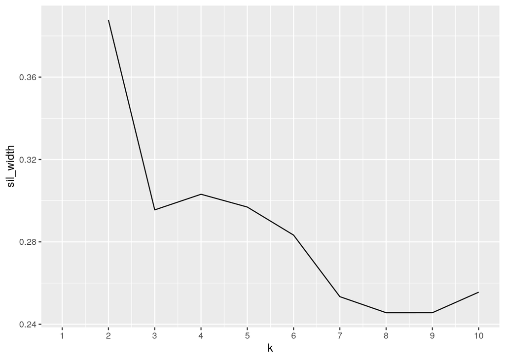

```r
library(cluster)
# clustering code here
poke_clust <- poke_join %>% select(HP, Sp.Atk, Sp.Def)

sil_width <- vector()
for (i in 2:10) {
    kms <- kmeans(poke_clust, centers = i)
    sil <- silhouette(kms$cluster, dist(poke_clust))
    sil_width[i] <- mean(sil[, 3])
}
ggplot() + geom_line(aes(x = 1:10, y = sil_width)) + scale_x_continuous(name = "k",
    breaks = 1:10)
```

```r
poke_pam <- poke_clust %>% pam(k = 2)
poke_pam$silinfo$avg.width
```

```
## [1] 0.3759268
```

```r
poke_clust %>% slice(poke_pam$id.med)
```

```
## # A tibble: 2 × 3
##      HP Sp.Atk Sp.Def
##   <dbl>  <dbl>  <dbl>
## 1    55     50     55
## 2    80     95     90
```

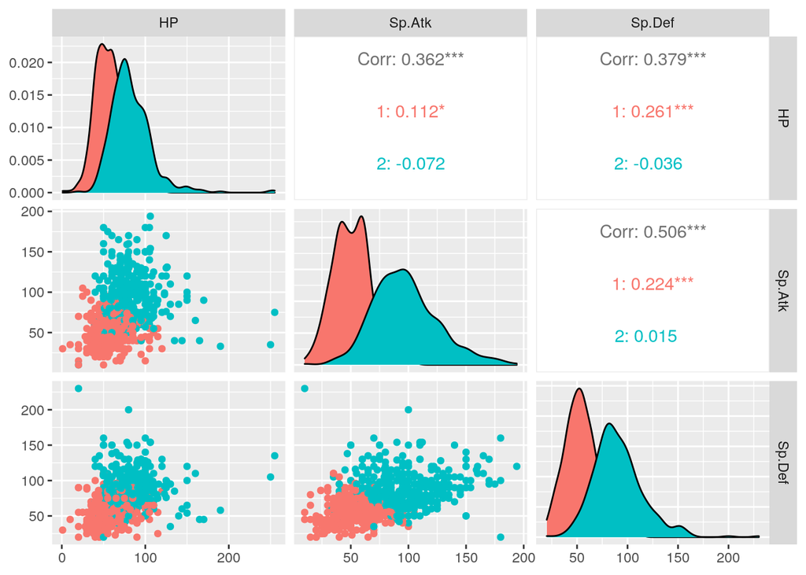

```r
library(GGally)
poke_clust %>% ungroup %>% mutate(cluster = as.factor(poke_pam$clustering)) %>%
    ggpairs(columns = 1:3, aes(color = cluster))
```

*The best k for the cluster solution was the one that gave the highest silhouette width, which was k=2. The three variables used for clustering were HP, Sp.Atk, and Sp.Def, and the silhouette width generated from the cluster was 0.3759, which conveys that the clustering is weak and the structure setup could be artificial, even if this was the best cluster results generated. There is a strong positive correlation between Sp.Atk and Sp.Def at 0.506. The rest of the correlations are moderate positive correlations, with HP and Sp.Atk having a correlation of 0.362, and HP and Sp.Def having a correlation of 0.379.*

### Dimensionality Reduction with PCA

```r
# PCA code here
poke_pca <- princomp(poke_clust, cor = T)
summary(poke_pca)
```

```
## Importance of components:
##                           Comp.1    Comp.2    Comp.3
## Standard deviation     1.3546319 0.8195489 0.7023617
## Proportion of Variance 0.6116759 0.2238868 0.1644373
## Cumulative Proportion  0.6116759 0.8355627 1.0000000
```

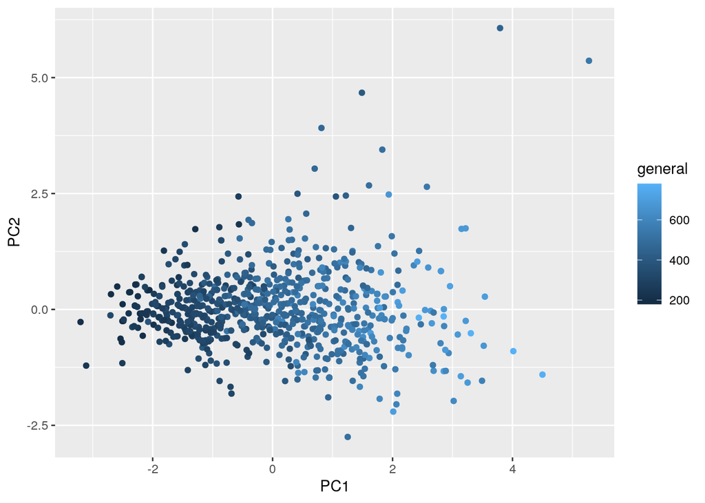

```r
poke_pca_matscores <- poke_pca$scores %>% as.data.frame %>% mutate(general = poke_join$Total)
poke_pca_matscores %>% ggplot(mapping = aes(x = poke_pca$scores[,
    1], y = poke_pca$scores[, 2], color = general)) + geom_point() +
    xlab("PC1") + ylab("PC2")
```

### Linear Classifier

```r
# linear classifier code here
logistic_fit <- glm(Legendary ~ HP + Attack + Defense + Sp.Atk +
    Sp.Def + Speed + height + weight + base_experience, data = poke_join,
    family = "binomial")

prob_reg <- predict(logistic_fit)
class_diag(prob_reg, poke_join$Legendary, positive = "TRUE")
```

```
##            acc   sens  spec  ppv     f1     ba    auc
## Metrics 0.9462 0.5077 0.985 0.75 0.6055 0.7464 0.9816
```

```r
# cross-validation of linear classifier here
set.seed(322)
k = 10

data <- sample_frac(poke_join)
folds <- rep(1:k, length.out = nrow(data))

diags <- NULL

i = 1
for (i in 1:k) {
    train <- data[folds != i, ]
    test <- data[folds == i, ]
    truth <- test$Legendary

    fit <- glm(Legendary ~ HP + Attack + Defense + Sp.Atk + Sp.Def +
        Speed + height + weight + base_experience, data = train,
        family = "binomial")

    probs <- predict(fit, newdata = test)

    diags <- rbind(diags, class_diag(probs, truth, positive = "TRUE"))
}

summarize_all(diags, mean)
```

```
##      acc    sens   spec     ppv      f1      ba     auc
## 1 0.9425 0.52786 0.9839 0.73143 0.57452 0.75588 0.98024
```

*All numeric variables, except for total stats, are included when classifying a Legendary Pokemon. The model achieves an accuracy of 0.9462, an F1 score of 0.6055, and an AUC of 0.9816 when using a linear classifier. Using k-fold cross-validation with k=10, the model achieves an accuracy of 0.9425, an F1 score of 0.57452, and an AUC of 0.98024. The model performs very well per AUC in both instances. There is no noticeable decrease when predicting out of sample because the difference between AUC without cross-validation and AUC with cross-validation is miniscule, so there are no signs of overfitting.*

### Non-Parametric Classifier

```r
library(caret)
# non-parametric classifier code here
knn_fit <- knn3(Legendary ~ HP + Attack + Defense + Sp.Atk +
    Sp.Def + Speed + height + weight + base_experience, data = poke_join)

prob_knn <- predict(knn_fit, poke_join)
class_diag(prob_knn[, 2], poke_join$Legendary, positive = "TRUE")
```

```
##            acc   sens   spec    ppv     f1     ba    auc
## Metrics 0.9675 0.7538 0.9864 0.8305 0.7903 0.8701 0.9887
```

```r
# cross-validation of np classifier here
set.seed(322)
k = 10

data <- sample_frac(poke_join)
folds <- rep(1:k, length.out = nrow(data))

diags <- NULL

i = 1
for (i in 1:k) {
    train <- data[folds != i, ]
    test <- data[folds == i, ]
    truth <- test$Legendary

    fit <- knn3(Legendary ~ HP + Attack + Defense + Sp.Atk +
        Sp.Def + Speed + height + weight + base_experience, data = train)

    # test model
    probs <- predict(fit, newdata = test)

    # get performance metrics for each fold
    diags <- rbind(diags, class_diag(probs[, 2], truth, positive = "TRUE"))
}

# average performance metrics across all folds
summarize_all(diags, mean)
```

```
##     acc    sens    spec    ppv      f1      ba     auc
## 1 0.945 0.66848 0.97133 0.6849 0.65758 0.81992 0.94214
```

*The model achieves an accuracy of 0.9675, an F1 score of 0.7903, and an AUC of 0.9887 when using a non-parametric classifier. When using k-folds cross-validation with k=10, the model achieves an accuracy of 0.945, an F1 score of 0.65758, and an AUC of 0.94214. The model performs very well per AUC and has a slightly larger AUC than the linear classifier without cross-validation. With cross-validation, the model performs worse with the non-parametric classifier compared to the linear classifier. Because there is a decrease in AUC, the model shows signs of overfitting.*

### Regression/Numeric Prediction

```r
# regression model code here
fit <- lm(Total ~ HP + Attack + Defense + Sp.Atk + Sp.Def + Speed,
    data = poke_join)
yhat <- predict(fit)
mean((poke_join$Total - yhat)^2)
```

```
## [1] 2.145692e-25
```

```r
# cross-validation of regression model here
set.seed(1234)
k = 5
data <- poke_join[sample(nrow(poke_join)), ]
folds <- cut(seq(1:nrow(poke_join)), breaks = k, labels = F)
diags <- NULL

for (i in 1:k) {
    train <- data[folds != i, ]
    test <- data[folds == i, ]

    fit <- lm(Total ~ HP + Attack + Defense + Sp.Atk + Sp.Def +
        Speed, data = train)
    yhat <- predict(fit, newdata = test)
    diags <- mean((test$Total - yhat)^2)
}
mean(diags)
```

```
## [1] 1.099508e-25
```

*For regression/numeric prediction, I predicted the total stats based on HP, Attack, Defense, Special Attack, Special Defense, and Speed. The mean squared error is 2.1457e-25 without cross-validation and it is 1.0995e-25 with cross-validation. The MSE is slightly less for cross-validation but the difference is small, so there is no signs of overfitting.*

### Python

```r
library(reticulate)
use_python("/usr/bin/python3", required = F)
who_dat_pokemon <- "It's"
cat(c(who_dat_pokemon, py$who_dat_pokemon))
```

```
## It's
```

```python
# python code here
who_dat_pokemon = "Pikachu"
print(r.who_dat_pokemon, who_dat_pokemon)
```

```
## It's Pikachu
```